# Statistical Inference Project: Part 2 - Basic Inferential Data Analysis

Mariana

06/02/2018

## Overview

The purpose of this analysis is to load the `ToothGrowth` data set from the datasets package in R and to perform some basic exploratory data analyses. More information about the dataset can be found [here](https://stat.ethz.ch/R-manual/R-devel/library/datasets/html/ToothGrowth.html).

This project consists of 4 parts:

1. Basic data summary
2. Basic exploratory analysis
3. Hypothesis testing
4. Conclusions drawn from the analysis

## 1. Data summary

First, load libraries

```r
library(ggplot2)
library(datasets)
library(dplyr)
library(gridExtra)
```

Basic summary of the data

```r
data("ToothGrowth")
str(ToothGrowth)
```

```
## 'data.frame':    60 obs. of  3 variables:
##  $ len : num  4.2 11.5 7.3 5.8 6.4 10 11.2 11.2 5.2 7 ...
##  $ supp: Factor w/ 2 levels "OJ","VC": 2 2 2 2 2 2 2 2 2 2 ...
##  $ dose: num  0.5 0.5 0.5 0.5 0.5 0.5 0.5 0.5 0.5 0.5 ...
```

```r
summary(ToothGrowth)
```

```
##       len        supp         dose
##  Min.   : 4.20   OJ:30   Min.   :0.500
##  1st Qu.:13.07   VC:30   1st Qu.:0.500
##  Median :19.25           Median :1.000
##  Mean   :18.81           Mean   :1.167
##  3rd Qu.:25.27           3rd Qu.:2.000
##  Max.   :33.90           Max.   :2.000
```

```r
head(ToothGrowth)
```

```
##    len supp dose
## 1  4.2   VC  0.5
## 2 11.5   VC  0.5
## 3  7.3   VC  0.5
## 4  5.8   VC  0.5
## 5  6.4   VC  0.5
## 6 10.0   VC  0.5
```

```r
table(ToothGrowth$supp, ToothGrowth$dose)
```

```
##
##      0.5  1  2
##   OJ  10 10 10
##   VC  10 10 10
```

## 2. Exploratory Data Analysis

Draw box plots to compare different dosages of orange juice and ascorbic acid to get a better understanding of their effects on tooth growth.

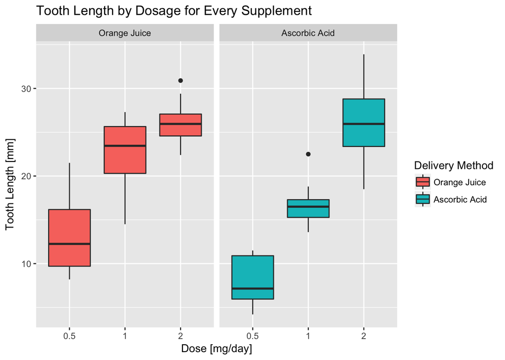

```r
data <- ToothGrowth
levels(data$supp) <- c("Orange Juice", "Ascorbic Acid")
ggplot(data, aes(x = factor(dose), y = len)) + facet_grid(.~supp) +
    geom_boxplot(aes(fill = supp)) + labs(title = "Tooth Length by Dosage for Every Supplement") +
    labs(x = "Dose [mg/day]", y = "Tooth Length [mm]") + scale_fill_discrete( name = "Delivery Method")
```

Orange juice shows better toothe length for 0.5 and 1 mg/day. The dosage of 2 mg/day has similar outcome for both delivery methods.

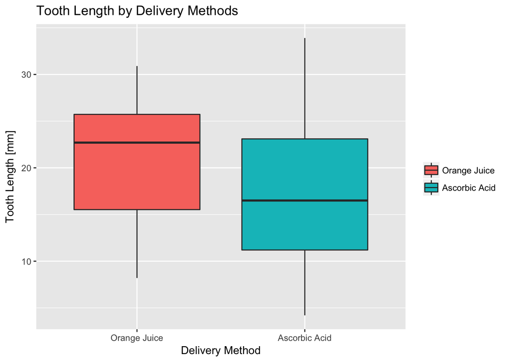

```r
ggplot(aes(x = supp, y = len), data = data) + geom_boxplot(aes(fill = supp)) +
  xlab("Delivery Method") + ylab("Tooth Length [mm]") +
  ggtitle("Tooth Length by Delivery Methods") + guides(fill=guide_legend(title=NULL))
```

Mean of delivery method

```r
deliveryMean <- split(data$len, data$supp)
sapply(deliveryMean, mean)
```

```
##  Orange Juice Ascorbic Acid
##      20.66333      16.96333
```

Both median and average of the tooth length for the orange juice treatment are greater than the ascorbic acid.

## 3. Hypothesis testing

##### Assumption:

Assume `ToothGrowth` data is normally distributed and also only that dose and supplement affect thooth growth.

**For 0.5 mg/day**

```r
t_0p5 <- t.test(len ~ supp, data = subset(data, dose == 0.5))
t_0p5$conf.int
```

```
## [1] 1.719057 8.780943
## attr(,"conf.level")
## [1] 0.95
```

```r
t_0p5$p.value
```

```
## [1] 0.006358607
```

For dose of 0.5 mg/day, p-value 0.0063586 is smaller than the significance level 0.05, thus $H_0$ can be safely rejected. So at this dose, orange juice and ascorbic acid are not equally effective for tooth growth. Orange juice would be the best option.

**For 1.0 mg/day**

```r
t_1p0 <- t.test(len ~ supp, data = subset(data, dose == 1.0))
t_1p0$conf.int
```

```
## [1] 2.802148 9.057852
## attr(,"conf.level")
## [1] 0.95
```

```r
t_1p0$p.value
```

```
## [1] 0.001038376
```

The 95% confidence interval is 2.8021482, 9.0578518. It does not contain zero and the p-value is 0.0010384, which is less than 0.05. $H_0$ can be safely rejected. Orange juice would be the best option for tooth growth at this dosage.

**For 2.0 mg/day**

```r
t_2p0 <- t.test(len ~ supp, data = subset(data, dose == 2.0))
t_2p0$conf.int
```

```
## [1] -3.79807  3.63807
## attr(,"conf.level")
## [1] 0.95
```

```r
t_2p0$p.value
```

```
## [1] 0.9638516
```

For dose of 2.0 mg/day, the confidence interval is -3.7980705, 3.6380705. It contains zero. p-value 0.9638516 is bigger than the significance level 0.05, thus $H_0$ cannot rejected.

## 4. Conclusions

For 0.5 and 1.0 mg/day, orange juice increases tooth length faster than ascorbic acid. For 2.0 mg/day there is no significant difference in the increase of tooth length. The results align with the exploratory boxplot shown in the `Exploratory Data Analysis` section.